# The Effect of Fans on an NBA Game

## Introduction

The NBA, or the National Basketball Association, was established in 1946. The 2021-2022 season will mark the league's 75th season. In that time, many games have been played at a variety of arenas. Over the years, it has become apparent that home-court advantage is real among many sports, especially basketball. It is possible to believe that home-court advantage can be traced back to the home team's fans that are attending the game.

In 2020, the World was hit by the COVID-19 pandemic causing many sports leagues to shut down for some time, including the NBA. When the NBA came back for the rest of the 2020 season, no fans were present at the games, but teams were playing at a neutral site. However, for the 2020-2021 NBA regular season, teams were back to playing at their home arenas, but with either no fans allowed, or limited fans allowed. So, the question becomes, what role do fans play in an NBA game? How much do they factor into the "home-court advantage" of an NBA team?

In this tutorial, I will go through the data science pipeline to show the effect that fans have on an NBA game. The goal is to collect and tidy some data from the last few NBA seasons, provide some specifics and visualize the home-court advantage with and without fans, and eventually predict the outcome of a game based on whether fans were present or not.

### Data Collection

```python
import pandas as pd
import numpy as np
import requests
import matplotlib.pyplot as plt
from sklearn import linear_model
import sqlite3 as sql
from datetime import date
from datetime import datetime
from statsmodels.formula.api import ols
from sklearn.linear_model import LinearRegression
import statsmodels.api as sm
import seaborn as sns
from sklearn import linear_model
import warnings
warnings.filterwarnings("ignore")
import statsmodels.formula.api as smf
#Import the database downloaded from below
# https://www.kaggle.com/datasets/wyattowalsh/basketball
```

```python
# Connect to the database. Collecting Data
conn = sql.connect('basketball.sqlite')
```

##### Parse the Data

I am interested in the wins and losses between and home team and away team. Additionally, I want the point differential from games to show what kind of effect fans may have on the competition. Therefore, I will only extract the following columns from the database in the code below. This will help me explore wins depending on home court and attendance.

```python
# Get the season, home team, away team, along with wins and losses.
no_fans_query = "SELECT SEASON_ID, GAME_DATE, WL_HOME, WL_AWAY, ATTENDANCE, PTS_HOME, PTS_AWAY, FG3M_HOME, FGM_HOME, FGA_HOME, FGM_AWAY, FG3M_AWAY, FGA_AWAY, FG_PCT_HOME, FG_PCT_AWAY, FG3_PCT_HOME, FG3_PCT_AWAY, FTA_HOME, FTA_AWAY, TOV_HOME, TOV_AWAY, OREB_HOME, OREB_AWAY, DREB_AWAY, DREB_HOME FROM Game"
df = pd.read_sql(no_fans_query, conn)
df
```

|  | SEASON_ID | GAME_DATE | WL_HOME | WL_AWAY | ATTENDANCE | PTS_HOME | PTS_AWAY | FG3M_HOME | FGM_HOME | FGA_HOME | ... | FG3_PCT_HOME | FG3_PCT_AWAY | FTA_HOME | FTA_AWAY | TOV_HOME | TOV_AWAY | OREB_HOME | OREB_AWAY | DREB_AWAY | DREB_HOME |
| --- | --- | --- | --- | --- | --- | --- | --- | --- | --- | --- | --- | --- | --- | --- | --- | --- | --- | --- | --- | --- | --- |
| 0 | 21946 | 1946-11-01 | L | W | None | 66 | 68 | None | 25.0 | None | ... | NaN | NaN | 29.0 | 26.0 | None | None | None | None | None | None |
| 1 | 21946 | 1946-11-02 | W | L | None | 56 | 51 | None | 20.0 | 59.0 | ... | NaN | NaN | NaN | NaN | None | None | None | None | None | None |
| 2 | 21946 | 1946-11-02 | W | L | None | 63 | 47 | None | 21.0 | None | ... | NaN | NaN | NaN | NaN | None | None | None | None | None | None |
| 3 | 21946 | 1946-11-02 | W | L | None | 59 | 53 | None | 21.0 | None | ... | NaN | NaN | NaN | NaN | None | None | None | None | None | None |
| 4 | 21946 | 1946-11-02 | L | W | None | 33 | 50 | None | 10.0 | None | ... | NaN | NaN | NaN | NaN | None | None | None | None | None | None |
| ... | ... | ... | ... | ... | ... | ... | ... | ... | ... | ... | ... | ... | ... | ... | ... | ... | ... | ... | ... | ... | ... |
| 62443 | 22020 | 2021-05-16 | W | L | 1939 | 132 | 116 | 18 | 46.0 | 87 | ... | 0.419 | 0.378 | 26.0 | 15.0 | 14 | 6 | 11 | 10 | 26 | 40 |
| 62444 | 22020 | 2021-05-16 | W | L | 1638 | 136 | 121 | 17 | 49.0 | 90 | ... | 0.425 | 0.421 | 25.0 | 20.0 | 10 | 16 | 11 | 11 | 27 | 27 |
| 62445 | 22020 | 2021-05-16 | W | L | 3427 | 118 | 112 | 14 | 45.0 | 87 | ... | 0.438 | 0.324 | 19.0 | 32.0 | 16 | 12 | 8 | 10 | 31 | 37 |
| 62446 | 22020 | 2021-05-16 | L | W | 3700 | 98 | 110 | 9 | 37.0 | 78 | ... | 0.360 | 0.314 | 21.0 | 15.0 | 21 | 10 | 8 | 8 | 34 | 39 |
| 62447 | 22020 | 2021-05-16 | L | W | None | 99 | 121 | 9 | 42.0 | 90 | ... | 0.300 | 0.462 | 10.0 | 25.0 | 13 | 16 | 5 | 9 | 41 | 34 |

62448 rows × 25 columns

From this dataset, I want to get the four factors of an NBA game. These factors are 4 of the most important factors when determining the outcome of a game or even season. Much of the information can be found from this source https://www.nbastuffer.com/analytics101/four-factors/. The four factors are, effective shooting percentage, turnover percentage, offensive rebounding percentage, and free throw rate. Below are the calculations for each of these factors.

```python
# All rates will be given in final as the home difference. That is, home - away.
# Effective shooting percentage
df['efg_home'] = (df['FGM_HOME'] + (.5 * df['FG3M_HOME'].astype(float))) / df['FGA_HOME'].astype(float)
df['efg_away'] = (df['FGM_AWAY'] + (.5 * df['FG3M_AWAY'].astype(float))) / df['FGA_AWAY'].astype(float)
df['efg_dif'] = (df['efg_home'] - df['efg_away']) * 100

# Turnover percentage
df['tov_home'] = df['TOV_HOME'].astype(float) / (df['FGA_HOME'].astype(float) + (.44 * df['FTA_HOME'].astype(float)) + df['TOV_HOME'].astype(float))
df['tov_away'] = df['TOV_AWAY'].astype(float) / (df['FGA_AWAY'].astype(float) + (.44 * df['FTA_AWAY'].astype(float)) + df['TOV_AWAY'].astype(float))
df['tov_pct_dif'] = (df['tov_home'] - df['tov_away'])* 100

# Offensive rebound percentage
df['oreb_home'] = df['OREB_HOME'].astype(float) / (df['OREB_HOME'].astype(float) + df['DREB_AWAY'].astype(float))
df['oreb_away'] = df['OREB_AWAY'].astype(float) / (df['OREB_AWAY'].astype(float) + df['DREB_HOME'].astype(float))
df['oreb_pct_dif'] = (df['oreb_home'] - df['oreb_away']) * 100

# Free throw rate
df['ft_home'] = df['FTA_HOME'].astype(float) / df['FGA_HOME'].astype(float)
df['ft_away'] = df['FTA_AWAY'].astype(float) / df['FGA_AWAY'].astype(float)
df['ft_pct_dif'] = (df['ft_home'] - df['ft_away']) * 100

# Drop all columns that are no longer needed
df = df.drop(columns = ['efg_home', 'efg_away', 'tov_home', 'tov_away', 'oreb_home', 'oreb_away', 'ft_home', 'ft_away'])
df
```

|  | SEASON_ID | GAME_DATE | WL_HOME | WL_AWAY | ATTENDANCE | PTS_HOME | PTS_AWAY | FG3M_HOME | FGM_HOME | FGA_HOME | ... | TOV_HOME | TOV_AWAY | OREB_HOME | OREB_AWAY | DREB_AWAY | DREB_HOME | efg_dif | tov_pct_dif | oreb_pct_dif | ft_pct_dif |
| --- | --- | --- | --- | --- | --- | --- | --- | --- | --- | --- | --- | --- | --- | --- | --- | --- | --- | --- | --- | --- | --- |
| 0 | 21946 | 1946-11-01 | L | W | None | 66 | 68 | None | 25.0 | None | ... | None | None | None | None | None | None | NaN | NaN | NaN | NaN |
| 1 | 21946 | 1946-11-02 | W | L | None | 56 | 51 | None | 20.0 | 59.0 | ... | None | None | None | None | None | None | NaN | NaN | NaN | NaN |
| 2 | 21946 | 1946-11-02 | W | L | None | 63 | 47 | None | 21.0 | None | ... | None | None | None | None | None | None | NaN | NaN | NaN | NaN |
| 3 | 21946 | 1946-11-02 | W | L | None | 59 | 53 | None | 21.0 | None | ... | None | None | None | None | None | None | NaN | NaN | NaN | NaN |
| 4 | 21946 | 1946-11-02 | L | W | None | 33 | 50 | None | 10.0 | None | ... | None | None | None | None | None | None | NaN | NaN | NaN | NaN |
| ... | ... | ... | ... | ... | ... | ... | ... | ... | ... | ... | ... | ... | ... | ... | ... | ... | ... | ... | ... | ... | ... |
| 62443 | 22020 | 2021-05-16 | W | L | 1939 | 132 | 116 | 18 | 46.0 | 87 | ... | 14 | 6 | 11 | 10 | 26 | 40 | 11.177574 | 7.026130 | 9.729730 | 14.578935 |
| 62444 | 22020 | 2021-05-16 | W | L | 1638 | 136 | 121 | 17 | 49.0 | 90 | ... | 10 | 16 | 11 | 11 | 27 | 27 | 6.746032 | -4.807917 | 0.000000 | 5.799756 |
| 62445 | 22020 | 2021-05-16 | W | L | 3427 | 118 | 112 | 14 | 45.0 | 87 | ... | 16 | 12 | 8 | 10 | 31 | 37 | 10.881226 | 4.030118 | -0.763775 | -13.716475 |
| 62446 | 22020 | 2021-05-16 | L | W | 3700 | 98 | 110 | 9 | 37.0 | 78 | ... | 21 | 10 | 8 | 8 | 34 | 39 | 0.600962 | 10.520336 | 2.026342 | 11.298077 |
| 62447 | 22020 | 2021-05-16 | L | W | None | 99 | 121 | 9 | 42.0 | 90 | ... | 13 | 16 | 5 | 9 | 41 | 34 | -6.472868 | -2.055009 | -10.060667 | -17.958656 |

62448 rows × 29 columns

### Data Representation

The scope of this project is to explore the effect that fans have on games. With this being the case, I am interested in the results of a specific season. This season is the year of 2020. To explore the data, I am going to want two datasets, one from the season of 2020, and one from seasons prior. These datasets will contain the attendance, and the wins and losses of the home teams and away teams from the seasons of 2009-2018 and 2020.

```python
fans_allowed = df # Copy over the data before modifying

df['SEASON_ID'] = df['SEASON_ID'].astype(int)
df_beforeyear = df[df['SEASON_ID'] < 22020]
df = df.drop(df_beforeyear.index) # Get data for only the season of 2020
no_fans = df
no_fans = no_fans.sort_values(by=['GAME_DATE']) # Sort by date
no_fans['HOME_PT_DIF'] = no_fans['PTS_HOME'] - no_fans['PTS_AWAY'] # Point differential for home team
no_fans = no_fans.fillna(value=0)
no_fans
```

|  | SEASON_ID | GAME_DATE | WL_HOME | WL_AWAY | ATTENDANCE | PTS_HOME | PTS_AWAY | FG3M_HOME | FGM_HOME | FGA_HOME | ... | TOV_AWAY | OREB_HOME | OREB_AWAY | DREB_AWAY | DREB_HOME | efg_dif | tov_pct_dif | oreb_pct_dif | ft_pct_dif | HOME_PT_DIF |
| --- | --- | --- | --- | --- | --- | --- | --- | --- | --- | --- | --- | --- | --- | --- | --- | --- | --- | --- | --- | --- | --- |
| 61363 | 22020 | 2020-12-22 | L | W | 0 | 109 | 116 | 9 | 38.0 | 81 | ... | 16 | 8 | 11 | 29 | 37 | -2.369574 | 3.086200 | -1.295045 | 17.841497 | -7 |
| 61364 | 22020 | 2020-12-22 | W | L | 0 | 125 | 99 | 15 | 42.0 | 92 | ... | 18 | 13 | 13 | 34 | 44 | 11.380105 | 1.703095 | 4.852557 | 11.550285 | 26 |
| 61365 | 22020 | 2020-12-23 | W | L | 0 | 113 | 107 | 8 | 41.0 | 87 | ... | 20 | 10 | 5 | 35 | 37 | -1.805274 | -2.144749 | 10.317460 | 7.423935 | 6 |
| 61366 | 22020 | 2020-12-23 | L | W | 0 | 104 | 124 | 8 | 36.0 | 87 | ... | 23 | 8 | 8 | 38 | 29 | -16.522989 | -5.253838 | -4.230317 | -4.066092 | -20 |
| 61367 | 22020 | 2020-12-23 | W | L | 0 | 106 | 102 | 11 | 38.0 | 79 | ... | 12 | 6 | 6 | 33 | 42 | 7.416232 | 6.225564 | 2.884615 | 3.588980 | 4 |
| ... | ... | ... | ... | ... | ... | ... | ... | ... | ... | ... | ... | ... | ... | ... | ... | ... | ... | ... | ... | ... | ... |
| 62435 | 22020 | 2021-05-16 | W | L | 1981 | 96 | 92 | 13 | 34.0 | 79 | ... | 12 | 4 | 9 | 37 | 37 | 4.172800 | -0.288867 | -9.809120 | 6.608772 | 4 |
| 62434 | 22020 | 2021-05-16 | W | L | 5333 | 115 | 110 | 10 | 44.0 | 91 | ... | 13 | 10 | 10 | 32 | 43 | 7.037643 | 1.196719 | 4.941599 | -2.454992 | 5 |
| 62433 | 22020 | 2021-05-16 | L | W | 0 | 113 | 125 | 12 | 39.0 | 97 | ... | 13 | 16 | 10 | 37 | 32 | -12.029300 | -1.359177 | 6.379155 | 10.949539 | -12 |
| 62439 | 22020 | 2021-05-16 | W | L | 3045 | 124 | 95 | 7 | 49.0 | 90 | ... | 16 | 11 | 11 | 32 | 45 | 14.855072 | -2.338966 | 5.938538 | 7.149758 | 29 |
| 62447 | 22020 | 2021-05-16 | L | W | 0 | 99 | 121 | 9 | 42.0 | 90 | ... | 16 | 5 | 9 | 41 | 34 | -6.472868 | -2.055009 | -10.060667 | -17.958656 | -22 |

1085 rows × 30 columns

```python
# Calculate the day of the year to get a measure of time for the season
base_date = pd.Timestamp('2020-12-21')
no_fans['GAME_DATE'] = no_fans['GAME_DATE'].astype('datetime64[ns]')
no_fans['DAY'] = (no_fans['GAME_DATE'] - base_date).dt.days
no_fans
```

|  | SEASON_ID | GAME_DATE | WL_HOME | WL_AWAY | ATTENDANCE | PTS_HOME | PTS_AWAY | FG3M_HOME | FGM_HOME | FGA_HOME | ... | OREB_HOME | OREB_AWAY | DREB_AWAY | DREB_HOME | efg_dif | tov_pct_dif | oreb_pct_dif | ft_pct_dif | HOME_PT_DIF | DAY |
| --- | --- | --- | --- | --- | --- | --- | --- | --- | --- | --- | --- | --- | --- | --- | --- | --- | --- | --- | --- | --- | --- |
| 61363 | 22020 | 2020-12-22 | L | W | 0 | 109 | 116 | 9 | 38.0 | 81 | ... | 8 | 11 | 29 | 37 | -2.369574 | 3.086200 | -1.295045 | 17.841497 | -7 | 1 |
| 61364 | 22020 | 2020-12-22 | W | L | 0 | 125 | 99 | 15 | 42.0 | 92 | ... | 13 | 13 | 34 | 44 | 11.380105 | 1.703095 | 4.852557 | 11.550285 | 26 | 1 |
| 61365 | 22020 | 2020-12-23 | W | L | 0 | 113 | 107 | 8 | 41.0 | 87 | ... | 10 | 5 | 35 | 37 | -1.805274 | -2.144749 | 10.317460 | 7.423935 | 6 | 2 |
| 61366 | 22020 | 2020-12-23 | L | W | 0 | 104 | 124 | 8 | 36.0 | 87 | ... | 8 | 8 | 38 | 29 | -16.522989 | -5.253838 | -4.230317 | -4.066092 | -20 | 2 |
| 61367 | 22020 | 2020-12-23 | W | L | 0 | 106 | 102 | 11 | 38.0 | 79 | ... | 6 | 6 | 33 | 42 | 7.416232 | 6.225564 | 2.884615 | 3.588980 | 4 | 2 |
| ... | ... | ... | ... | ... | ... | ... | ... | ... | ... | ... | ... | ... | ... | ... | ... | ... | ... | ... | ... | ... | ... |
| 62435 | 22020 | 2021-05-16 | W | L | 1981 | 96 | 92 | 13 | 34.0 | 79 | ... | 4 | 9 | 37 | 37 | 4.172800 | -0.288867 | -9.809120 | 6.608772 | 4 | 146 |
| 62434 | 22020 | 2021-05-16 | W | L | 5333 | 115 | 110 | 10 | 44.0 | 91 | ... | 10 | 10 | 32 | 43 | 7.037643 | 1.196719 | 4.941599 | -2.454992 | 5 | 146 |
| 62433 | 22020 | 2021-05-16 | L | W | 0 | 113 | 125 | 12 | 39.0 | 97 | ... | 16 | 10 | 37 | 32 | -12.029300 | -1.359177 | 6.379155 | 10.949539 | -12 | 146 |
| 62439 | 22020 | 2021-05-16 | W | L | 3045 | 124 | 95 | 7 | 49.0 | 90 | ... | 11 | 11 | 32 | 45 | 14.855072 | -2.338966 | 5.938538 | 7.149758 | 29 | 146 |
| 62447 | 22020 | 2021-05-16 | L | W | 0 | 99 | 121 | 9 | 42.0 | 90 | ... | 5 | 9 | 41 | 34 | -6.472868 | -2.055009 | -10.060667 | -17.958656 | -22 | 146 |

1085 rows × 31 columns

```python
# Parsing through the data for the 2009-2018 seasons.
fans_allowed['SEASON_ID'] = fans_allowed['SEASON_ID'].astype(int)
fans_beforeyear = fans_allowed[fans_allowed['SEASON_ID'] < 22009]

fans_allowed = fans_allowed.drop(fans_beforeyear.index)
fans_allowed = fans_allowed[fans_allowed['SEASON_ID'] < 22019] # Data for ten seasons

fans_allowed = fans_allowed.sort_values(by=['GAME_DATE']) # Sort by date
fans_allowed['HOME_PT_DIF'] = fans_allowed['PTS_HOME'] - fans_allowed['PTS_AWAY'] # Point differential for home team
base_date = pd.Timestamp('2009-10-26')
fans_allowed['GAME_DATE'] = fans_allowed['GAME_DATE'].astype('datetime64[ns]')
fans_allowed['DAY'] = (fans_allowed['GAME_DATE'] - base_date).dt.days
fans_allowed
```

|  | SEASON_ID | GAME_DATE | WL_HOME | WL_AWAY | ATTENDANCE | PTS_HOME | PTS_AWAY | FG3M_HOME | FGM_HOME | FGA_HOME | ... | OREB_HOME | OREB_AWAY | DREB_AWAY | DREB_HOME | efg_dif | tov_pct_dif | oreb_pct_dif | ft_pct_dif | HOME_PT_DIF | DAY |
| --- | --- | --- | --- | --- | --- | --- | --- | --- | --- | --- | --- | --- | --- | --- | --- | --- | --- | --- | --- | --- | --- |
| 48184 | 22009 | 2009-10-27 | W | L | 18997 | 99 | 92 | 4 | 35.0 | 85 | ... | 17 | 15 | 36 | 30 | -3.022312 | -3.895141 | -1.257862 | 25.138607 | 7 | 1 |
| 48185 | 22009 | 2009-10-27 | L | W | 20562 | 89 | 95 | 6 | 29.0 | 70 | ... | 6 | 6 | 32 | 26 | -4.980159 | -1.816043 | -2.960526 | 9.603175 | -6 | 1 |
| 48186 | 22009 | 2009-10-27 | L | W | 19871 | 91 | 102 | 4 | 30.0 | 76 | ... | 11 | 9 | 37 | 31 | -6.704261 | 0.341026 | 0.416667 | 16.165414 | -11 | 1 |
| 48187 | 22009 | 2009-10-27 | W | L | 20403 | 96 | 87 | 10 | 33.0 | 77 | ... | 12 | 10 | 23 | 39 | 9.227193 | 8.496933 | 13.877551 | -7.231041 | 9 | 1 |
| 48199 | 22009 | 2009-10-28 | L | W | 17212 | 74 | 96 | 2 | 26.0 | 72 | ... | 17 | 10 | 29 | 32 | -18.055556 | 6.142858 | 13.146998 | 2.777778 | -22 | 2 |
| ... | ... | ... | ... | ... | ... | ... | ... | ... | ... | ... | ... | ... | ... | ... | ... | ... | ... | ... | ... | ... | ... |
| 60298 | 22018 | 2019-04-10 | W | L | 19814 | 136 | 131 | 14 | 53.0 | 91 | ... | 14 | 12 | 23 | 30 | 4.475733 | 2.589183 | 9.266409 | 7.509158 | 5 | 3453 |
| 60299 | 22018 | 2019-04-10 | L | W | 18082 | 116 | 127 | 15 | 43.0 | 100 | ... | 11 | 9 | 44 | 42 | -9.601010 | 1.030253 | 2.352941 | 7.868687 | -11 | 3453 |
| 60300 | 22018 | 2019-04-10 | L | W | 17143 | 134 | 135 | 17 | 43.0 | 103 | ... | 22 | 13 | 30 | 39 | -2.040816 | 5.938557 | 17.307692 | -2.902714 | -1 | 3453 |
| 60301 | 22018 | 2019-04-10 | W | L | 16332 | 99 | 95 | 10 | 39.0 | 87 | ... | 12 | 7 | 34 | 41 | 0.574713 | 2.446489 | 11.503623 | 12.946823 | 4 | 3453 |
| 60303 | 22018 | 2019-04-10 | W | L | 17794 | 132 | 117 | 21 | 48.0 | 98 | ... | 15 | 9 | 30 | 34 | 2.628660 | -3.074026 | 12.403101 | 3.149956 | 15 | 3453 |

12120 rows × 31 columns

As we can see, there is a big difference in the attendance between the two seasons/datasets. The 2020 season has games with either attendance as 0 or it is a fraction of the attendance listed for the seasons of 2009-2018. Splitting up these seasons will give me the ability to compare the home-court advantage given the attendance from the two datasets.

### Exploratory Data Analysis

The first topic we want to explore is how important home court is when playing an NBA game. To do this, I will display the number of wins by the home team throughout the seasons with fans allowed vs the number of losses by the home team.

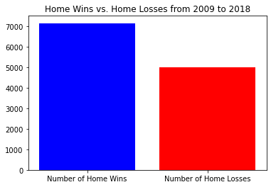

```python
# Compare the number of wins for home teams to number of losses
home_wins = fans_allowed['WL_HOME'].value_counts().W
home_losses = fans_allowed['WL_HOME'].value_counts().L

colors = ['blue', 'red']
plt.bar(["Number of Home Wins", "Number of Home Losses"], [home_wins, home_losses], color=colors)
plt.title("Home Wins vs. Home Losses from 2009 to 2018")
```

Now I want to compare the above data with the number of wins for home teams in the COVID season where no fans were allowed.

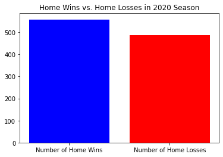

```python
# Compare the number of wins for home teams to number of losses
home_wins_cov = no_fans['WL_HOME'].value_counts().W
home_losses_cov = no_fans['WL_HOME'].value_counts().L

colors = ['blue', 'red']
plt.bar(["Number of Home Wins", "Number of Home Losses"], [home_wins_cov, home_losses_cov], color=colors)
plt.title("Home Wins vs. Home Losses in 2020 Season")
```

As we can see, the disparity between the number of home wins and losses is much smaller for the season where fans were at very limited capacity. Next, I want to see the effect that fans have on point differential when it comes to home-court advantage.

In order to truly see the effect of point differential on the fans, we will want to manipulate the data a bit. We want to get a measure of point differential across time when it comes to the home team. To do this, we will create a few variables that track the number of games in a day, the total number of home games up to a certain day, and the total home point differential up to a specific game. These variables will help visualize the home court advantage over a season plus the difference fans make in a game.

```python
fans_allowed2018 = fans_allowed[fans_allowed['SEASON_ID'] == 22018]
fans_allowed2018['NUM_GAMES_DAY'] = fans_allowed2018.groupby('DAY')['DAY'].transform('count') # Count the number of games per day

# Preventing from the number of games being counted multiple times
fans_allowed2018['is_dup'] = fans_allowed2018.duplicated(subset=['DAY'])

# Copy over the number of games in that day to later be counted
for i, c in fans_allowed2018.iterrows():
    if (fans_allowed2018.at[i, 'is_dup'] == False):
        fans_allowed2018.at[i, 'is_dup'] = c['NUM_GAMES_DAY']
# replace all the dups with 0
fans_allowed2018 = fans_allowed2018.replace(True, 0)

# Add up all games played up to this day
fans_allowed2018['TOTAL_HOME_GAMES'] = fans_allowed2018.is_dup.cumsum()
fans_allowed2018 = fans_allowed2018.drop(columns = ['is_dup'])
# Add up all pointt dif for all games
fans_allowed2018['TOTAL_PT_DIF_HOME'] = fans_allowed2018['HOME_PT_DIF'].cumsum()
# Get data from one year so it can fit into plot

fans_allowed2018
```

|  | SEASON_ID | GAME_DATE | WL_HOME | WL_AWAY | ATTENDANCE | PTS_HOME | PTS_AWAY | FG3M_HOME | FGM_HOME | FGA_HOME | ... | DREB_HOME | efg_dif | tov_pct_dif | oreb_pct_dif | ft_pct_dif | HOME_PT_DIF | DAY | NUM_GAMES_DAY | TOTAL_HOME_GAMES | TOTAL_PT_DIF_HOME |
| --- | --- | --- | --- | --- | --- | --- | --- | --- | --- | --- | --- | --- | --- | --- | --- | --- | --- | --- | --- | --- | --- |
| 59074 | 22018 | 2018-10-16 | W | L | 19596 | 108 | 100 | 7 | 42.0 | 95 | ... | 41 | 6.136495 | 4.679489 | 8.886346 | -21.711972 | 8 | 3277 | 2 | 2 | 8 |
| 59075 | 22018 | 2018-10-16 | W | L | 18624 | 105 | 87 | 11 | 42.0 | 97 | ... | 43 | 7.015049 | -1.449620 | 10.396611 | -12.003792 | 18 | 3277 | 2 | 2 | 26 |
| 59080 | 22018 | 2018-10-17 | W | L | 19191 | 104 | 101 | 7 | 39.0 | 94 | ... | 37 | 1.398333 | -3.715059 | -0.527903 | 10.298311 | 3 | 3278 | 11 | 13 | 29 |
| 59085 | 22018 | 2018-10-17 | L | W | 17889 | 112 | 113 | 16 | 41.0 | 92 | ... | 32 | -4.386189 | -8.530525 | -9.217759 | 0.383632 | -1 | 3278 | 11 | 13 | 28 |
| 59084 | 22018 | 2018-10-17 | L | W | 17583 | 117 | 123 | 7 | 49.0 | 95 | ... | 32 | -4.863424 | -7.040160 | -2.149877 | -29.153897 | -6 | 3278 | 11 | 13 | 22 |
| ... | ... | ... | ... | ... | ... | ... | ... | ... | ... | ... | ... | ... | ... | ... | ... | ... | ... | ... | ... | ... | ... |
| 60298 | 22018 | 2019-04-10 | W | L | 19814 | 136 | 131 | 14 | 53.0 | 91 | ... | 30 | 4.475733 | 2.589183 | 9.266409 | 7.509158 | 5 | 3453 | 11 | 1230 | 3344 |
| 60299 | 22018 | 2019-04-10 | L | W | 18082 | 116 | 127 | 15 | 43.0 | 100 | ... | 42 | -9.601010 | 1.030253 | 2.352941 | 7.868687 | -11 | 3453 | 11 | 1230 | 3333 |
| 60300 | 22018 | 2019-04-10 | L | W | 17143 | 134 | 135 | 17 | 43.0 | 103 | ... | 39 | -2.040816 | 5.938557 | 17.307692 | -2.902714 | -1 | 3453 | 11 | 1230 | 3332 |
| 60301 | 22018 | 2019-04-10 | W | L | 16332 | 99 | 95 | 10 | 39.0 | 87 | ... | 41 | 0.574713 | 2.446489 | 11.503623 | 12.946823 | 4 | 3453 | 11 | 1230 | 3336 |
| 60303 | 22018 | 2019-04-10 | W | L | 17794 | 132 | 117 | 21 | 48.0 | 98 | ... | 34 | 2.628660 | -3.074026 | 12.403101 | 3.149956 | 15 | 3453 | 11 | 1230 | 3351 |

1230 rows × 34 columns

```python
# Do the same thing for this dataset
no_fans['NUM_GAMES_DAY'] = no_fans.groupby('DAY')['DAY'].transform('count')
no_fans['is_dup'] = no_fans.duplicated(subset=['DAY'])
for i, c in no_fans.iterrows():
    if (no_fans.at[i, 'is_dup'] == False):
        no_fans.at[i, 'is_dup'] = c['NUM_GAMES_DAY']
no_fans = no_fans.replace(True, 0)
no_fans['TOTAL_HOME_GAMES'] = no_fans.is_dup.cumsum()
no_fans = no_fans.drop(columns = ['is_dup'])
no_fans['TOTAL_PT_DIF_HOME'] = no_fans['HOME_PT_DIF'].cumsum()

no_fans
```

|  | SEASON_ID | GAME_DATE | WL_HOME | WL_AWAY | ATTENDANCE | PTS_HOME | PTS_AWAY | FG3M_HOME | FGM_HOME | FGA_HOME | ... | DREB_HOME | efg_dif | tov_pct_dif | oreb_pct_dif | ft_pct_dif | HOME_PT_DIF | DAY | NUM_GAMES_DAY | TOTAL_HOME_GAMES | TOTAL_PT_DIF_HOME |
| --- | --- | --- | --- | --- | --- | --- | --- | --- | --- | --- | --- | --- | --- | --- | --- | --- | --- | --- | --- | --- | --- |
| 61363 | 22020 | 2020-12-22 | L | W | 0 | 109 | 116 | 9 | 38.0 | 81 | ... | 37 | -2.369574 | 3.086200 | -1.295045 | 17.841497 | -7 | 1 | 2 | 2 | -7 |
| 61364 | 22020 | 2020-12-22 | W | L | 0 | 125 | 99 | 15 | 42.0 | 92 | ... | 44 | 11.380105 | 1.703095 | 4.852557 | 11.550285 | 26 | 1 | 2 | 2 | 19 |
| 61365 | 22020 | 2020-12-23 | W | L | 0 | 113 | 107 | 8 | 41.0 | 87 | ... | 37 | -1.805274 | -2.144749 | 10.317460 | 7.423935 | 6 | 2 | 12 | 14 | 25 |
| 61366 | 22020 | 2020-12-23 | L | W | 0 | 104 | 124 | 8 | 36.0 | 87 | ... | 29 | -16.522989 | -5.253838 | -4.230317 | -4.066092 | -20 | 2 | 12 | 14 | 5 |
| 61367 | 22020 | 2020-12-23 | W | L | 0 | 106 | 102 | 11 | 38.0 | 79 | ... | 42 | 7.416232 | 6.225564 | 2.884615 | 3.588980 | 4 | 2 | 12 | 14 | 9 |
| ... | ... | ... | ... | ... | ... | ... | ... | ... | ... | ... | ... | ... | ... | ... | ... | ... | ... | ... | ... | ... | ... |
| 62435 | 22020 | 2021-05-16 | W | L | 1981 | 96 | 92 | 13 | 34.0 | 79 | ... | 37 | 4.172800 | -0.288867 | -9.809120 | 6.608772 | 4 | 146 | 15 | 1085 | 995 |
| 62434 | 22020 | 2021-05-16 | W | L | 5333 | 115 | 110 | 10 | 44.0 | 91 | ... | 43 | 7.037643 | 1.196719 | 4.941599 | -2.454992 | 5 | 146 | 15 | 1085 | 1000 |
| 62433 | 22020 | 2021-05-16 | L | W | 0 | 113 | 125 | 12 | 39.0 | 97 | ... | 32 | -12.029300 | -1.359177 | 6.379155 | 10.949539 | -12 | 146 | 15 | 1085 | 988 |
| 62439 | 22020 | 2021-05-16 | W | L | 3045 | 124 | 95 | 7 | 49.0 | 90 | ... | 45 | 14.855072 | -2.338966 | 5.938538 | 7.149758 | 29 | 146 | 15 | 1085 | 1017 |
| 62447 | 22020 | 2021-05-16 | L | W | 0 | 99 | 121 | 9 | 42.0 | 90 | ... | 34 | -6.472868 | -2.055009 | -10.060667 | -17.958656 | -22 | 146 | 15 | 1085 | 995 |

1085 rows × 34 columns

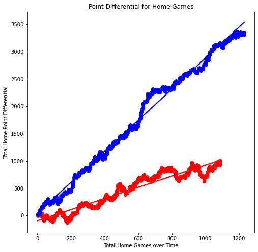

```python
# Plotting the point differential for the home team across the season
plt.figure(figsize = (8, 8))
sns.regplot(x=no_fans['TOTAL_HOME_GAMES'], y=no_fans['TOTAL_PT_DIF_HOME'], color = 'red')
sns.regplot(x=fans_allowed2018['TOTAL_HOME_GAMES'], y=fans_allowed2018['TOTAL_PT_DIF_HOME'], color = 'blue')
plt.title("Point Differential for Home Games")
plt.xlabel("Total Home Games over Time")
plt.ylabel("Total Home Point Differential")
```

The above graph shows the accumulating point differential for the home team as home games accumulate. This ultimately shows very interesting data. The red data marks that of the "COVID season" where fans were held to very limited attendance. The blue data shows a regular season where fans attend at full capacity. Based on the above graph, it would appear that fans play a very important role in terms of point differential as home point differential increases at a much greater rate over time when fans allowed. However, let's look at just how important fans are in a game by game scenario.

```python
# Combine the two datasets
frames = [fans_allowed, no_fans]
df = pd.concat(frames)
# Get rid of columns that aren't needed
df = df.drop(columns = ['NUM_GAMES_DAY', 'TOTAL_HOME_GAMES', 'TOTAL_PT_DIF_HOME'])
df
```

|  | SEASON_ID | GAME_DATE | WL_HOME | WL_AWAY | ATTENDANCE | PTS_HOME | PTS_AWAY | FG3M_HOME | FGM_HOME | FGA_HOME | ... | OREB_HOME | OREB_AWAY | DREB_AWAY | DREB_HOME | efg_dif | tov_pct_dif | oreb_pct_dif | ft_pct_dif | HOME_PT_DIF | DAY |
| --- | --- | --- | --- | --- | --- | --- | --- | --- | --- | --- | --- | --- | --- | --- | --- | --- | --- | --- | --- | --- | --- |
| 48184 | 22009 | 2009-10-27 | W | L | 18997 | 99 | 92 | 4 | 35.0 | 85 | ... | 17 | 15 | 36 | 30 | -3.022312 | -3.895141 | -1.257862 | 25.138607 | 7 | 1 |
| 48185 | 22009 | 2009-10-27 | L | W | 20562 | 89 | 95 | 6 | 29.0 | 70 | ... | 6 | 6 | 32 | 26 | -4.980159 | -1.816043 | -2.960526 | 9.603175 | -6 | 1 |
| 48186 | 22009 | 2009-10-27 | L | W | 19871 | 91 | 102 | 4 | 30.0 | 76 | ... | 11 | 9 | 37 | 31 | -6.704261 | 0.341026 | 0.416667 | 16.165414 | -11 | 1 |
| 48187 | 22009 | 2009-10-27 | W | L | 20403 | 96 | 87 | 10 | 33.0 | 77 | ... | 12 | 10 | 23 | 39 | 9.227193 | 8.496933 | 13.877551 | -7.231041 | 9 | 1 |
| 48199 | 22009 | 2009-10-28 | L | W | 17212 | 74 | 96 | 2 | 26.0 | 72 | ... | 17 | 10 | 29 | 32 | -18.055556 | 6.142858 | 13.146998 | 2.777778 | -22 | 2 |
| ... | ... | ... | ... | ... | ... | ... | ... | ... | ... | ... | ... | ... | ... | ... | ... | ... | ... | ... | ... | ... | ... |
| 62435 | 22020 | 2021-05-16 | W | L | 1981 | 96 | 92 | 13 | 34.0 | 79 | ... | 4 | 9 | 37 | 37 | 4.172800 | -0.288867 | -9.809120 | 6.608772 | 4 | 146 |
| 62434 | 22020 | 2021-05-16 | W | L | 5333 | 115 | 110 | 10 | 44.0 | 91 | ... | 10 | 10 | 32 | 43 | 7.037643 | 1.196719 | 4.941599 | -2.454992 | 5 | 146 |
| 62433 | 22020 | 2021-05-16 | L | W | 0 | 113 | 125 | 12 | 39.0 | 97 | ... | 16 | 10 | 37 | 32 | -12.029300 | -1.359177 | 6.379155 | 10.949539 | -12 | 146 |
| 62439 | 22020 | 2021-05-16 | W | L | 3045 | 124 | 95 | 7 | 49.0 | 90 | ... | 11 | 11 | 32 | 45 | 14.855072 | -2.338966 | 5.938538 | 7.149758 | 29 | 146 |
| 62447 | 22020 | 2021-05-16 | L | W | 0 | 99 | 121 | 9 | 42.0 | 90 | ... | 5 | 9 | 41 | 34 | -6.472868 | -2.055009 | -10.060667 | -17.958656 | -22 | 146 |

13205 rows × 31 columns

OLS Regression Results

| Dep. Variable: | HOME_PT_DIF | R-squared (uncentered): | 0.040 |
| --- | --- | --- | --- |
| Model: | OLS | Adj. R-squared (uncentered): | 0.040 |
| Method: | Least Squares | F-statistic: | 554.2 |
| Date: | Tue, 10 May 2022 | Prob (F-statistic): | 4.46e-120 |
| Time: | 02:31:42 | Log-Likelihood: | -53160. |
| No. Observations: | 13205 | AIC: | 1.063e+05 |
| Df Residuals: | 13204 | BIC: | 1.063e+05 |
| Df Model: | 1 |  |  |
| Covariance Type: | nonrobust |  |  |

|  | coef | std err | t | P>\|t\| | [0.025 | 0.975] |
| --- | --- | --- | --- | --- | --- | --- |
| ATTENDANCE | 0.0002 | 6.94e-06 | 23.542 | 0.000 | 0.000 | 0.000 |

| Omnibus: | 22.366 | Durbin-Watson: | 1.987 |
| --- | --- | --- | --- |
| Prob(Omnibus): | 0.000 | Jarque-Bera (JB): | 27.077 |
| Skew: | -0.003 | Prob(JB): | 1.32e-06 |
| Kurtosis: | 3.222 | Cond. No. | 1.00 |

Notes:  
[1] R² is computed without centering (uncentered) since the model does not contain a constant.  
[2] Standard Errors assume that the covariance matrix of the errors is correctly specified.

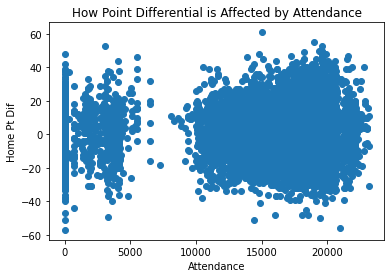

```python
from sklearn import linear_model
df = df.fillna(value=0) # Fill in all None's with 0s
df['ATTENDANCE'] = df['ATTENDANCE'].astype(float)
# Linear model for how attendance affects point differential
model = sm.OLS(df['HOME_PT_DIF'], df['ATTENDANCE'])
plt.scatter(df['ATTENDANCE'], df['HOME_PT_DIF'])
plt.title("How Point Differential is Affected by Attendance")
plt.ylabel("Home Pt Dif")
plt.xlabel("Attendance")
model=model.fit()
model.summary()
```

Based on the above linear model, it is clear that there is a relationship between attendance and home point differential as the resulting p value is 0. This is significant as we see a coefficient of .0002 for attendance. For every one fan, we see a .0002 increase in home point differential. When the fans start getting up into the 10000 and 20000, this can become a substantial difference. However, given the scatter plot and the low R-squared, it appears that there is more going on than just attendance affecting point differential., Because this is the case, it is important to look at some other factors of the game that could be impacted by the attendance, and ultimately impact the point differential.

Some important factors that can determine the outcome of a basketball game include things like shooting percentage, free throws, turnovers, and rebounds. To get a measure of this, I want to explore the effects that attendance has on the road and home team in these categories by finding the difference in terms of the home team. First, I would like to explore just how much of an effect that these factors have on a game.

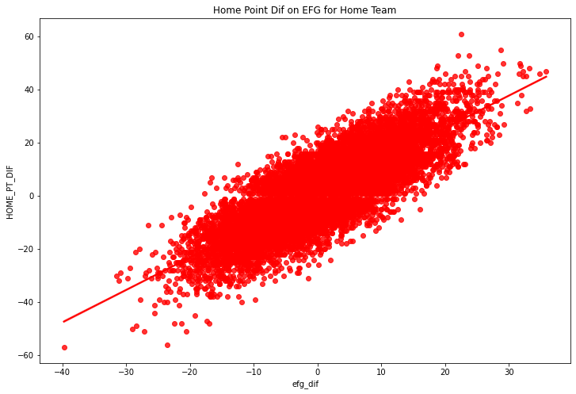

```python
plt.figure(figsize = (12, 8))
# Plot the efg
sns.regplot(x=df['efg_dif'], y=df['HOME_PT_DIF'], color = 'red')
plt.title("Home Point Dif on EFG for Home Team")
```

From the above plot, we see a strong correlation between increase in the difference of effective field goal percentage for the home team and home point differential. This shows just how strong of a factor the shooting percentage is in an NBA game. It is important to consider this factor when explaining the point differential of a game. Now, we will look at the other important factors of a game.

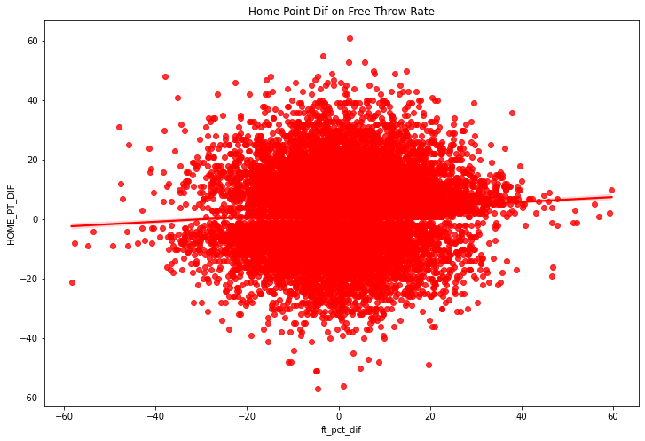

```python
plt.figure(figsize = (12, 8))
sns.regplot(x=df['ft_pct_dif'], y=df['HOME_PT_DIF'], color = 'red')
plt.title("Home Point Dif on Free Throw Rate")
```

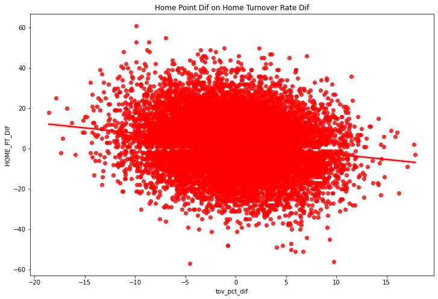

```python
plt.figure(figsize = (12, 8))
sns.regplot(x=df['tov_pct_dif'], y=df['HOME_PT_DIF'], color = 'red')
plt.title("Home Point Dif on Home Turnover Rate Dif")
```

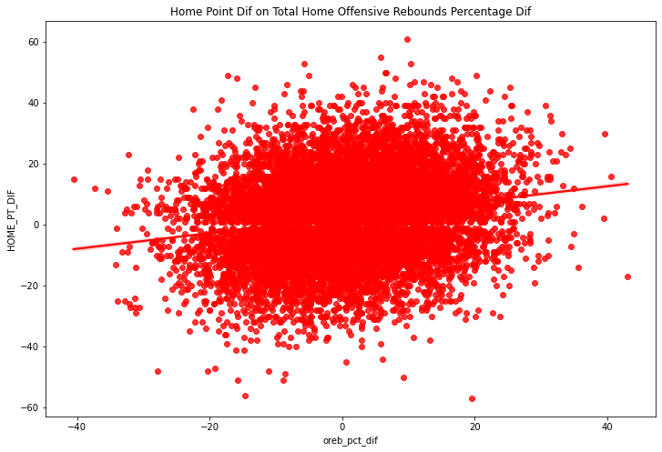

```python
plt.figure(figsize = (12, 8))
sns.regplot(x=df['oreb_pct_dif'], y=df['HOME_PT_DIF'], color = 'red')
plt.title("Home Point Dif on Total Home Offensive Rebounds Percentage Dif")
```

The above results show just how important these factors are in terms of point differential for the home team. By looking at the plots, it would appear that the difference in rebounds and turnovers in respect to the home team have a stronger correlation in relation to home point differential. As the home team has a higher differential in turnovers, that means they are turning the ball over more, which, according to the plot, leads to a worse point differential for the home team. Additionally, we see that a positive difference in rebounds for the home team leads to greater point differential. Finally, the free throw rate also plays an important role in the determination of the game. There also appears to be a correlation for free throw rate and home point differential.

When thinking about how fans may have an impact on a game, it would be important to see which factors of the game might be affected the most. One common thought with sports is that the home team gets the benefit of the doubt when it comes to officiating. This would come into play with the free throw rate. As a result, I want to take a look at how the free throw rate might be affected by fans. To do this I will compare the free throw rate to when there are fans and when there are no fans.

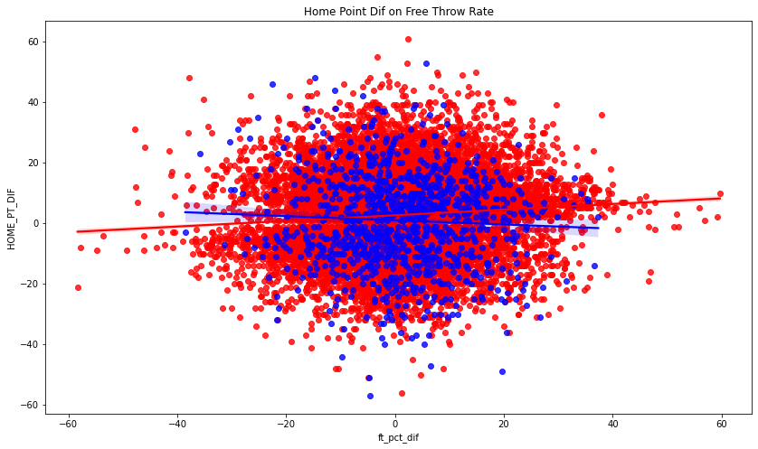

```python
plt.figure(figsize = (14, 8))
sns.regplot(x=fans_allowed['ft_pct_dif'], y=fans_allowed['HOME_PT_DIF'], color = 'red')
sns.regplot(x=no_fans['ft_pct_dif'], y=no_fans['HOME_PT_DIF'], color = 'blue')
plt.title("Home Point Dif on Free Throw Rate")
```

It would appear that the affect that free throw rate has on home point differential is much different when fans are not at the game or are limited.

```python
fans_allowed.describe()
```

|  | SEASON_ID | PTS_HOME | PTS_AWAY | FGM_HOME | FGM_AWAY | FG_PCT_HOME | FG_PCT_AWAY | FG3_PCT_HOME | FG3_PCT_AWAY | FTA_HOME | FTA_AWAY | efg_dif | tov_pct_dif | oreb_pct_dif | ft_pct_dif | HOME_PT_DIF | DAY |
| --- | --- | --- | --- | --- | --- | --- | --- | --- | --- | --- | --- | --- | --- | --- | --- | --- | --- |
| count | 12120.000000 | 12120.000000 | 12120.000000 | 12120.000000 | 12120.000000 | 12120.000000 | 12120.000000 | 12120.000000 | 12120.000000 | 12120.000000 | 12120.000000 | 12120.000000 | 12120.000000 | 12120.000000 | 12120.000000 | 12120.000000 | 12120.000000 |
| mean | 22013.548680 | 103.603218 | 100.852558 | 38.667904 | 37.741914 | 0.462305 | 0.451078 | 0.357477 | 0.349696 | 23.600990 | 22.668729 | 1.219030 | -0.276068 | 0.880754 | 1.132573 | 2.750660 | 1748.827805 |
| std | 2.872734 | 12.600296 | 12.548194 | 5.189107 | 5.085446 | 0.056015 | 0.054542 | 0.106645 | 0.105305 | 7.532937 | 7.311517 | 9.001815 | 4.644700 | 10.527796 | 13.157867 | 13.431512 | 1045.266707 |
| min | 22009.000000 | 59.000000 | 56.000000 | 19.000000 | 16.000000 | 0.279000 | 0.246000 | 0.000000 | 0.000000 | 1.000000 | 1.000000 | -31.511628 | -18.596206 | -40.537084 | -58.333333 | -56.000000 | 1.000000 |
| 25% | 22011.000000 | 95.000000 | 92.000000 | 35.000000 | 34.000000 | 0.424000 | 0.415000 | 0.286000 | 0.280000 | 18.000000 | 18.000000 | -4.863612 | -3.376205 | -6.309524 | -7.317073 | -7.000000 | 863.000000 |
| 50% | 22014.000000 | 103.000000 | 100.000000 | 38.000000 | 38.000000 | 0.461000 | 0.450000 | 0.357000 | 0.350000 | 23.000000 | 22.000000 | 1.219512 | -0.261222 | 0.952381 | 1.191571 | 4.000000 | 1840.000000 |
| 75% | 22016.000000 | 112.000000 | 109.000000 | 42.000000 | 41.000000 | 0.500000 | 0.488000 | 0.429000 | 0.419000 | 28.000000 | 27.000000 | 7.241482 | 2.857365 | 8.049536 | 9.695988 | 11.000000 | 2646.000000 |
| max | 22018.000000 | 161.000000 | 168.000000 | 62.000000 | 58.000000 | 0.684000 | 0.667000 | 0.889000 | 0.783000 | 64.000000 | 64.000000 | 35.855263 | 17.855640 | 43.103448 | 59.687500 | 61.000000 | 3453.000000 |

```python
no_fans.describe()
```

|  | SEASON_ID | PTS_HOME | PTS_AWAY | FGM_HOME | FGM_AWAY | FG_PCT_HOME | FG_PCT_AWAY | FG3_PCT_HOME | FG3_PCT_AWAY | FTA_HOME | FTA_AWAY | efg_dif | tov_pct_dif | oreb_pct_dif | ft_pct_dif | HOME_PT_DIF | DAY | NUM_GAMES_DAY | TOTAL_HOME_GAMES | TOTAL_PT_DIF_HOME |
| --- | --- | --- | --- | --- | --- | --- | --- | --- | --- | --- | --- | --- | --- | --- | --- | --- | --- | --- | --- | --- |
| count | 1085.0 | 1085.000000 | 1085.000000 | 1085.000000 | 1085.000000 | 1085.000000 | 1085.000000 | 1085.000000 | 1085.000000 | 1085.000000 | 1085.000000 | 1085.000000 | 1085.000000 | 1085.000000 | 1085.000000 | 1085.000000 | 1085.000000 | 1085.000000 | 1085.000000 | 1085.000000 |
| mean | 22020.0 | 111.176037 | 110.258986 | 40.752995 | 40.715207 | 0.469333 | 0.465394 | 0.368904 | 0.362432 | 21.878341 | 21.095853 | 0.575491 | 0.324753 | 0.490717 | 1.070672 | 0.917051 | 76.069124 | 8.445161 | 546.722581 | 461.172350 |
| std | 0.0 | 14.396320 | 14.794790 | 5.850364 | 5.867935 | 0.055822 | 0.053681 | 0.085389 | 0.086611 | 7.187650 | 7.051343 | 9.635583 | 4.706311 | 9.792770 | 11.346488 | 15.163638 | 42.796004 | 2.192739 | 313.476138 | 335.110461 |
| min | 22020.0 | 18.000000 | 16.000000 | 7.000000 | 6.000000 | 0.277000 | 0.271000 | 0.089000 | 0.083000 | 2.000000 | 4.000000 | -39.748369 | -13.255650 | -28.019324 | -38.537936 | -57.000000 | 1.000000 | 2.000000 | 2.000000 | -130.000000 |
| 25% | 22020.0 | 102.000000 | 102.000000 | 37.000000 | 37.000000 | 0.430000 | 0.427000 | 0.313000 | 0.308000 | 17.000000 | 16.000000 | -5.875831 | -2.701163 | -6.212121 | -5.982236 | -9.000000 | 39.000000 | 7.000000 | 275.000000 | 160.000000 |
| 50% | 22020.0 | 112.000000 | 111.000000 | 41.000000 | 41.000000 | 0.468000 | 0.466000 | 0.368000 | 0.359000 | 22.000000 | 20.000000 | 0.743707 | 0.299007 | 0.203978 | 0.962567 | 2.000000 | 80.000000 | 9.000000 | 547.000000 | 528.000000 |
| 75% | 22020.0 | 121.000000 | 120.000000 | 45.000000 | 45.000000 | 0.506000 | 0.500000 | 0.429000 | 0.422000 | 26.000000 | 26.000000 | 7.047301 | 3.385699 | 6.818182 | 8.081395 | 11.000000 | 114.000000 | 10.000000 | 822.000000 | 741.000000 |
| max | 22020.0 | 154.000000 | 152.000000 | 63.000000 | 57.000000 | 0.673000 | 0.655000 | 0.645000 | 0.636000 | 47.000000 | 46.000000 | 33.338983 | 15.868306 | 33.771107 | 37.323481 | 53.000000 | 146.000000 | 15.000000 | 1085.000000 | 1017.000000 |

The above results allow me to compare the home court advantages in terms of the factors of a game. This allows me to see the differences in the home factor averages like points, rebounds, shooting percentages, and turnovers. Through analysis of these results, it would appear that many of the averages are higher when fans are allowed than when fans were limited in 2020. This gives reason to believe that fans have a bit of an impact on the game. From these results, we would think that fans cause about a 1.8 point increase in the home team's point differential. However, there is more to look at as we should look at the interactions of these variables, as well as if we can conclude that fans actually cause a difference on these variables.

### Hypothesis Testing and Regression

To determine if there is a conclusive difference between rebounds, points, shooting percentage free throws, and turnovers when there are fans and when there are no fans, we will want to visualize the interactions that the fans have on the factors of the game. To do this, I will want to plot out each of the factors and how they effect the home point differential, but distinguish the two seasons. This will allow us to see if there are interacting terms for fans versus no fans.

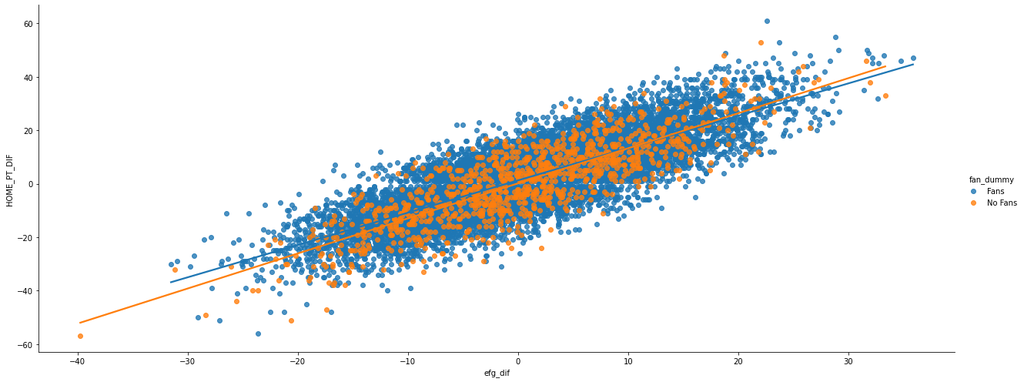

```python
df['fan_dummy'] = 'Fans'
for i, c in df.iterrows():
    if (c['SEASON_ID'] == 22020):
        df.at[i, 'fan_dummy'] = 'No Fans'

sns.lmplot(x='efg_dif', y='HOME_PT_DIF', hue='fan_dummy', data=df, ci = None, size = 7, aspect = 2.5)
```

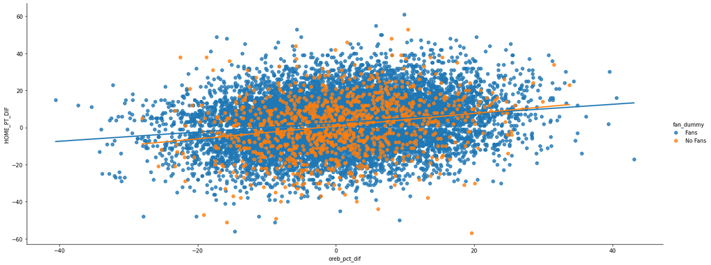

```python
sns.lmplot(x='oreb_pct_dif', y='HOME_PT_DIF', hue='fan_dummy', data=df, ci = None, size = 7, aspect = 2.5)
```

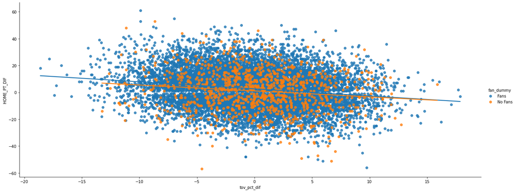

```python
sns.lmplot(x='tov_pct_dif', y='HOME_PT_DIF', hue='fan_dummy', data=df, ci = None, size = 7, aspect = 2.5)
```

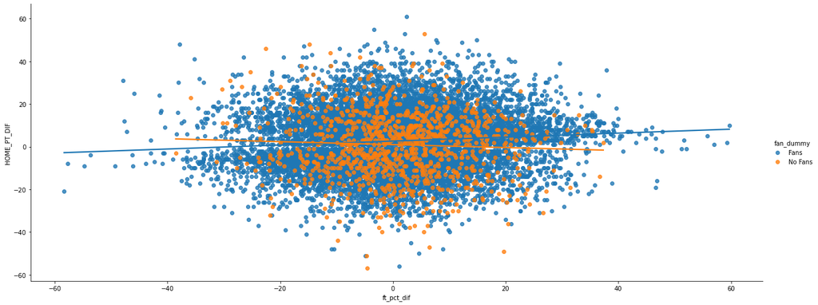

```python
sns.lmplot(x='ft_pct_dif', y='HOME_PT_DIF', hue='fan_dummy', data=df, ci = None, size = 7, aspect = 2.5)
```

Based on the plots, it would appear that there are interactions for fans with the free throw rate. This will be important to note when thinking about regression.

To create these regression models, we will need multiple linear regression. I want to use multiple linear regression and machine learning to test and train my data as I would would like to know how strong the relationship is between the factors and home point differential. Using multiple linear regression and machine learning models can be found at this source https://www.analyticsvidhya.com/blog/2021/05/multiple-linear-regression-using-python-and-scikit-learn/. I will train and test my data to predict home point differentials which will eventually be compared to the true value.

```python
# # Predict outcome of the game by predicting the point differential based off of the season/fans
# # and other above discussed factors of the game
from sklearn import model_selection
# First regress for seasons with fans
testdf = fans_allowed[['efg_dif', 'oreb_pct_dif', 'tov_pct_dif', 'ft_pct_dif']]
X = testdf
y = fans_allowed['HOME_PT_DIF']
X_train, X_test, y_train, y_test = model_selection.train_test_split(X, y, test_size = .4, random_state=0)
X_train['HOME_PT_DIF'] = y_train
regr = smf.ols('HOME_PT_DIF ~ oreb_pct_dif + efg_dif + tov_pct_dif + ft_pct_dif', data = X_train).fit()
regr.params
```

```
Intercept       0.099078
oreb_pct_dif    0.430556
efg_dif         1.402001
tov_pct_dif    -1.219443
ft_pct_dif      0.155328
dtype: float64
```

```python
preds = regr.predict(X_test)
```

```python
res = pd.DataFrame({'Actual': y_test, 'Predicted': preds})
# Display residuals
res
```

|  | Actual | Predicted |
| --- | --- | --- |
| 54726 | 7 | 2.515843 |
| 57335 | 17 | 15.251448 |
| 56428 | -5 | -11.494322 |
| 51937 | -5 | -2.879139 |
| 48896 | 17 | 11.759563 |
| ... | ... | ... |
| 55335 | 9 | 7.549862 |
| 56151 | -6 | -9.126961 |
| 57604 | -6 | -1.201688 |
| 59438 | 28 | 23.846321 |
| 53347 | -9 | -6.808005 |

4848 rows × 2 columns

```python
from sklearn import metrics
# Show some metrics of the model
print("MSE: ", metrics.mean_absolute_error(y_test, preds))
```

```
MSE:  2.985035281602306
```

```python
from sklearn.metrics import r2_score
print("Coefficient of Determination: ", r2_score(y_test, preds))
```

```
Coefficient of Determination:  0.9224326173976941
```

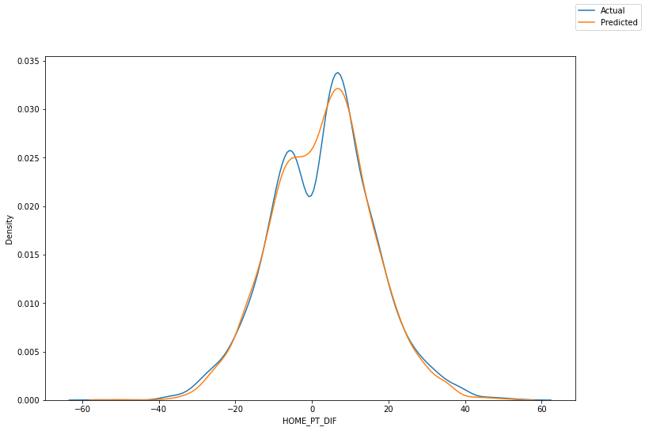

```python
fig, ax = plt.subplots(figsize = (12, 8))
sns.distplot(y_test, hist=False, label = 'Actual', ax=ax)
sns.distplot(preds, hist=False, label = "Predicted", ax=ax)
fig.legend(labels=['Actual', 'Predicted'])
plt.show()
```

```python
# Perform an F test to check the signifcance of the model
from scipy.stats import f
F = np.var(preds)/np.var(y_test)
test = f.cdf(F, len(preds-1), len(y_test-1))
print("P Value for Model: ", test)
```

```
P Value for Model:  0.0005970689514424815
```

The model for the seasons with fans performs very well as it has a very small p value. It takes in all four important factors of a basketball game. It takes effective shooting, free throw rate, offensive rebounding rate, and turnover percentage. We expect this to perform well as there is plenty of data and there is nothing out of the ordinary going on the seasons. I will compare this regression model to that of a season with no fans.

```python
# regress for seasons without fans
# Exact same method just using different dataset
testdf = no_fans[['efg_dif', 'oreb_pct_dif', 'tov_pct_dif', 'ft_pct_dif']]
X = testdf
y = no_fans['HOME_PT_DIF']
X_train, X_test, y_train, y_test = model_selection.train_test_split(X, y, test_size = .4, random_state=0)
X_train['HOME_PT_DIF'] = y_train
regr = smf.ols('HOME_PT_DIF ~ oreb_pct_dif + efg_dif + ft_pct_dif + tov_pct_dif', data = X_train).fit()
regr.params
```

```
Intercept       0.065226
oreb_pct_dif    0.474916
efg_dif         1.546702
ft_pct_dif      0.137654
tov_pct_dif    -1.364352
dtype: float64
```

```python
preds = regr.predict(X_test)
print("Coefficient of Determination: ", r2_score(y_test, preds))
```

```
Coefficient of Determination:  0.9286315012554036
```

```python
F = np.var(preds)/np.var(y_test)
test = f.cdf(F, len(preds-1), len(y_test-1))
print("P Value for Model: ", test)
```

```
P Value for Model:  0.32710208985571926
```

This model performs well with a high coefficient of determination. However, the p value for the model is greater than the significance level of .05, signifying that the model is not producing significant results. This could be from the smaller sample size, or it could have to do with fact that the model is less fitting given that fans are not at play. However, this model has a high R-squared value indicating that much of the variation in the home point differential is predictable from the four factors. Given that we can see just how much these four factors impact a basketball game, let's conclude with some final regressions on how a season with fans impacts each of the four factors.

```python
# Effective Field Goal Percentage
mods = ols('efg_dif ~ C(fan_dummy)', data=df).fit()
mods.summary()
```

OLS Regression Results

| Dep. Variable: | efg_dif | R-squared: | 0.000 |
| --- | --- | --- | --- |
| Model: | OLS | Adj. R-squared: | 0.000 |
| Method: | Least Squares | F-statistic: | 5.029 |
| Date: | Tue, 10 May 2022 | Prob (F-statistic): | 0.0249 |
| Time: | 02:31:52 | Log-Likelihood: | -47832. |
| No. Observations: | 13205 | AIC: | 9.567e+04 |
| Df Residuals: | 13203 | BIC: | 9.568e+04 |
| Df Model: | 1 |  |  |
| Covariance Type: | nonrobust |  |  |

|  | coef | std err | t | P>\|t\| | [0.025 | 0.975] |
| --- | --- | --- | --- | --- | --- | --- |
| Intercept | 1.2190 | 0.082 | 14.820 | 0.000 | 1.058 | 1.380 |
| C(fan_dummy)[T.No Fans] | -0.6435 | 0.287 | -2.243 | 0.025 | -1.206 | -0.081 |

| Omnibus: | 1.504 | Durbin-Watson: | 1.995 |
| --- | --- | --- | --- |
| Prob(Omnibus): | 0.471 | Jarque-Bera (JB): | 1.474 |
| Skew: | 0.018 | Prob(JB): | 0.479 |
| Kurtosis: | 3.037 | Cond. No. | 3.67 |

Notes:  
[1] Standard Errors assume that the covariance matrix of the errors is correctly specified.

In a season with no fans, it appears that the effective field goal percentage drops by about 0.64 percent.

```python
# Free throw rate
mods = ols('ft_pct_dif ~ C(fan_dummy)', data=df).fit()
mods.summary()
```

OLS Regression Results

| Dep. Variable: | ft_pct_dif | R-squared: | 0.000 |
| --- | --- | --- | --- |
| Model: | OLS | Adj. R-squared: | -0.000 |
| Method: | Least Squares | F-statistic: | 0.02251 |
| Date: | Tue, 10 May 2022 | Prob (F-statistic): | 0.881 |
| Time: | 02:31:52 | Log-Likelihood: | -52625. |
| No. Observations: | 13205 | AIC: | 1.053e+05 |
| Df Residuals: | 13203 | BIC: | 1.053e+05 |
| Df Model: | 1 |  |  |
| Covariance Type: | nonrobust |  |  |

|  | coef | std err | t | P>\|t\| | [0.025 | 0.975] |
| --- | --- | --- | --- | --- | --- | --- |
| Intercept | 1.1326 | 0.118 | 9.577 | 0.000 | 0.901 | 1.364 |
| C(fan_dummy)[T.No Fans] | -0.0619 | 0.413 | -0.150 | 0.881 | -0.871 | 0.747 |

| Omnibus: | 60.130 | Durbin-Watson: | 2.011 |
| --- | --- | --- | --- |
| Prob(Omnibus): | 0.000 | Jarque-Bera (JB): | 83.839 |
| Skew: | -0.017 | Prob(JB): | 6.23e-19 |
| Kurtosis: | 3.389 | Cond. No. | 3.67 |

Notes:  
[1] Standard Errors assume that the covariance matrix of the errors is correctly specified.

In a season with no fans, it appears that we would expect the free throw rate to drop by .06. However, it comes with a large p-value, so we cannot conclude that there is a relationship between having fans and not. There may be other factors at play with free throw rate, such as who is winning and end of game situations, that we could not capture in this tutorial.

```python
# Turnover rate
mods = ols('tov_pct_dif ~ C(fan_dummy)', data=df).fit()
mods.summary()
```

OLS Regression Results

| Dep. Variable: | tov_pct_dif | R-squared: | 0.001 |
| --- | --- | --- | --- |
| Model: | OLS | Adj. R-squared: | 0.001 |
| Method: | Least Squares | F-statistic: | 16.63 |
| Date: | Tue, 10 May 2022 | Prob (F-statistic): | 4.58e-05 |
| Time: | 02:31:52 | Log-Likelihood: | -39030. |
| No. Observations: | 13205 | AIC: | 7.806e+04 |
| Df Residuals: | 13203 | BIC: | 7.808e+04 |
| Df Model: | 1 |  |  |
| Covariance Type: | nonrobust |  |  |

|  | coef | std err | t | P>\|t\| | [0.025 | 0.975] |
| --- | --- | --- | --- | --- | --- | --- |
| Intercept | -0.2761 | 0.042 | -6.536 | 0.000 | -0.359 | -0.193 |
| C(fan_dummy)[T.No Fans] | 0.6008 | 0.147 | 4.078 | 0.000 | 0.312 | 0.890 |

| Omnibus: | 1.515 | Durbin-Watson: | 2.000 |
| --- | --- | --- | --- |
| Prob(Omnibus): | 0.469 | Jarque-Bera (JB): | 1.513 |
| Skew: | -0.026 | Prob(JB): | 0.469 |
| Kurtosis: | 3.000 | Cond. No. | 3.67 |

Notes:  
[1] Standard Errors assume that the covariance matrix of the errors is correctly specified.

In a season with no fans, we would expect, with significance, that the turnover rate increase by .6 percent.

```python
# Offensive Rebounding Percentage
mods = ols('oreb_pct_dif ~ C(fan_dummy)', data=df).fit()
mods.summary()
```

OLS Regression Results

| Dep. Variable: | oreb_pct_dif | R-squared: | 0.000 |
| --- | --- | --- | --- |
| Model: | OLS | Adj. R-squared: | 0.000 |
| Method: | Least Squares | F-statistic: | 1.382 |
| Date: | Tue, 10 May 2022 | Prob (F-statistic): | 0.240 |
| Time: | 02:31:53 | Log-Likelihood: | -49747. |
| No. Observations: | 13205 | AIC: | 9.950e+04 |
| Df Residuals: | 13203 | BIC: | 9.951e+04 |
| Df Model: | 1 |  |  |
| Covariance Type: | nonrobust |  |  |

|  | coef | std err | t | P>\|t\| | [0.025 | 0.975] |
| --- | --- | --- | --- | --- | --- | --- |
| Intercept | 0.8808 | 0.095 | 9.262 | 0.000 | 0.694 | 1.067 |
| C(fan_dummy)[T.No Fans] | -0.3900 | 0.332 | -1.176 | 0.240 | -1.040 | 0.260 |

| Omnibus: | 0.304 | Durbin-Watson: | 2.002 |
| --- | --- | --- | --- |
| Prob(Omnibus): | 0.859 | Jarque-Bera (JB): | 0.331 |
| Skew: | -0.001 | Prob(JB): | 0.847 |
| Kurtosis: | 2.976 | Cond. No. | 3.67 |

Notes:  
[1] Standard Errors assume that the covariance matrix of the errors is correctly specified.

In a season with no fans, we would expect the offensive rebound rate to decrease by .39 percent. However, again there is a large p value so we do not have sufficient evidence to believe the relationship.

As part of a conclusion, I would like to make a regresion on the whole dataset, including both fans and no fans, and see if we can do any better than the previous regressions. I will include a categorical variable for fans, which, based on the above interaction plots, will also have an interaction with the free throw rate variable.

```python
# regress for all seasons
testdf = df[['efg_dif', 'oreb_pct_dif', 'tov_pct_dif', 'ft_pct_dif', 'fan_dummy']]
X = testdf
y = df['HOME_PT_DIF']
X_train, X_test, y_train, y_test = model_selection.train_test_split(X, y, test_size = .4, random_state=0)
X_train['HOME_PT_DIF'] = y_train
lr = smf.ols('HOME_PT_DIF ~ C(fan_dummy) + oreb_pct_dif + efg_dif + ft_pct_dif + tov_pct_dif + C(fan_dummy):ft_pct_dif', data = X_train).fit()
lr.params
```

```
Intercept                             0.120282
C(fan_dummy)[T.No Fans]              -0.045073
oreb_pct_dif                          0.437591
efg_dif                               1.417443
ft_pct_dif                            0.154090
C(fan_dummy)[T.No Fans]:ft_pct_dif   -0.019389
tov_pct_dif                          -1.230555
dtype: float64
```

```python
y_pred = lr.predict(X_test)
print("Coefficient of Determination: ", r2_score(y_test, y_pred))
```

```
Coefficient of Determination:  0.9208025266155482
```

```python
F = np.var(y_pred)/np.var(y_test)
test = f.cdf(F, len(y_pred-1), len(y_test-1))
print("P Value for Model: ", test)
```

```
P Value for Model:  0.0014064589597955685
```

Taking note of the p value this model for the goodness of fit, it results in a very small p value. Additionally, including this model has a high coefficient of determination.

# Conclusion

In conclusion, this tutorial has laid out various aspects of an NBA basketball game while focusing on a few main things. I discussed the four main factors of a basketball game while going into detail about just how much these effect the game for the home team. Additionally, I discussed just how important home court could be with and without fans. Through some visualization and analysis, it was seen that there was some difference between home point differential with fans and without fans. It was important to note just how much fans effected the main factors of the game and if we could actually conclude that there was a significant difference. Throughout this tutorial, I have been able to show that fans do indeed have an slight impact on home court advantage.

Through the completion of this tutorial, I have gained much more experience and knowledge of the data science pipeline. Additionally, it has opened my eye to new factors of an NBA game. It has shown me how important statistics are in sports, and how statistics can be used to predict games.

In terms of future exploration, this was just the beginning of the impact that fans have on an NBA game. There is much more that could be explored, for example the next step could to be to look at how much each specified number of fans impact the game in each of the factors above. Addtionally, there are many aspects of the game to be thought about in which fans could impact the game. This was just the first step at determining the importance of fans.